# Mountain Bike (MTB) Categorization Analysis

Michael Czerwinski & Justin Schulberg

2022-04-17

# Introduction

## Project Overview

For this project, our team will determine whether the specifications of mountain bikes (MTB) are enough to differentiate between the different types of mountain bike categories.

Currently, full suspension mountain bikes come in multiple categories:

- **Cross Country (XC)** | Tend to be the most lightweight, nimble, and designed to put the rider in an efficient pedaling position
- **Enduro (EN)** | Heavier frames, more travel and more downhill oriented geometry
- **Trail (TR)** | The most common category of bikes, considered to be the halfway point between XC and Enduro
- **All Mountain (AM)** | A more niche category which some manufacturers claim to be more downhill focused than trail bikes, but not designed for downhill races like Enduro bikes are
- **Downcountry (DC)** | A relatively new category between XC and Trail. Similar to the All Mountain category, these bikes aren’t race specific like XC bikes tend to be, but are lighter and faster than trail bikes.

With all of the factors to consider when designing a bike, there are no clear boundaries between these categories. For example, one brand’s Downcountry bike could be what another brand considers a Trail bike. The popular mountain biking website PinkBike has done in-depth analyses of many bikes across all categories, and covered the topics of which category bikes should be classified as and of how many categories is sufficient, as seen in the video [here](https://www.youtube.com/watch?v=JYQJbymyG6k&ab_channel=Pinkbike).

**The goal of our project is to determine how many, if any, discrete categories should exist for mountain bikes.** Since most specifications and geometric measurements have one direction when moving across the spectrum of bikes, it’s reasonable to believe that these measurements could be reduced to much fewer dimensions, and perhaps even one continuous principle component rather than discrete categories. We can also cluster the bikes together based on some of these specifications and geometric measurements.

As an example, here is a diagram of some of the different types of geometric specifications on mountain bikes:

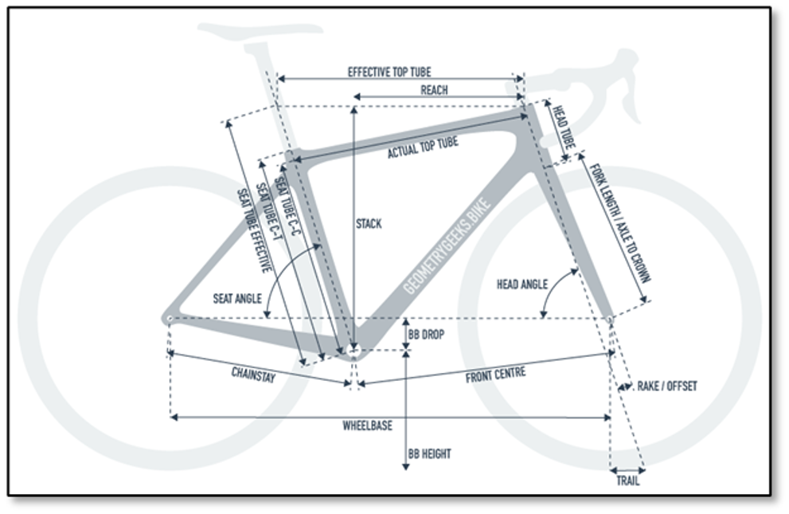

Various Dimension Features of a Bike’s Geometry

## The Data

The data was retrieved manually from each of the mountain bike company’s websites. All data and associated code for this project is available at the team’s corresponding [GitHub repository](https://github.com/mczerwin/MTB-Categorization-Analysis). Let’s take a look at the data.

| Model | Brand | Build Type | Price | Url | Image | Setting | Size Used | Label | Rear Travel | Fork Travel | F Piston | F Rotor Dim | R Piston | R Rotor Dim | Head Angle | Seat Angle | Crank Length | Stem Length | Handlebar Width | Reach | Stack | Wheelbase | Chainstay Length | Bb Height | Standover Height | Bike Category |
| --- | --- | --- | --- | --- | --- | --- | --- | --- | --- | --- | --- | --- | --- | --- | --- | --- | --- | --- | --- | --- | --- | --- | --- | --- | --- | --- |
| element | rocky mountain |  |  | https://bikes.com/collections/element |  | pos3 | L | xc | 120 | 130 | 2 | 180 | 2 | 180 | 65.50 | 76.5 | 170 | 50 | 780 | 480 | 627 | 1231 |  |  | 809 | Cross Country |
| instinct | rocky mountain | Carbon 90 | 9799 | https://bikes.com/collections/instinct |  | pos3 | L | tr | 140 | 150 |  |  |  |  | 65.50 | 76.5 | 170 | 40 | 780 | 435 | 629 | 1277 |  |  | 800 | Trail |
| Altitude | Rocky Mountain | Carbon 90 Rally Edition | 10229 | https://bikes.com/collections/altitude |  | pos3 | L | en | 160 | 170 |  |  |  |  | 64.80 | 75.8 | 170 | 40 | 780 | 478 | 635 | 1249 |  |  | 815 | Enduro |
| jeffsy | yt | Uncaged 6 | 9499 | https://us.yt-industries.com/products/bikes/465/jeffsy-uncaged-6/preview | https://cdn-prod.yt-industries.com/media/image/03/eb/be/Jeffsy_29_CF_SuperPro_Seite.png |  | L | am |  | 150 |  |  |  |  | 66.00 | 77.0 | 175 | 50 | 780 | 470 | 627 | 1218 | 435 | 344 | 701 | All Mountain |
| izzo | yt | Uncaged 7 | 7499 | https://us.yt-industries.com/products/bikes/466/izzo-uncaged-7/preview | https://cdn-prod.yt-industries.com/media/image/28/aa/9a/07_Izzo_29_CF_SuperLIGHT_SideVcEjYkvRoG6p2.png |  | L | tr |  | 120 |  |  |  |  | 66.50 | 77.5 | 170 | 50 | 740 | 475 | 619 | 1206 | 432 | 332 | 714 | Trail |
| Capra | Yt | Uncaged 9 | 3999 | https://us.yt-industries.com/products/bikes/428/capra-uncaged-9/preview | https://cdn-prod.yt-industries.com/media/image/8b/17/03/Capra_MX_SHRED2_Side.png |  | L | en |  | 170 |  |  |  |  | 64.20 | 77.6 | 170 | 50 | 800 | 467 | 634 | 1248 | 438 | 349 | 735 | Enduro |
| revolver | Norco | Revolver FS AXS 120 | 10999 | https://www.norco.com/bikes/2021/mountain/xc-race/revolver-fs-120/revolver-fs-axs-120/ | https://www.norco.com/cmsb/uploads/bikes/bikes/my21_revolver_fs_c_axs_29_120_black_silver-full.webp |  | L | xc | 120 | 120 |  | 180 |  | 160 | 67.40 | 74.9 | 175 | 60 | 780 | 478 | 597 | 1188 |  | 341 | 717 | Cross Country |
| optic | Norco | Optic C AXS | 10499 | https://www.norco.com/bikes/2021/mountain/trail/optic/optic-c-axs/ | https://www.norco.com/cmsb/uploads/bikes/bikes/my21_optic_c_axs_29_black_chrome-full.webp |  | L | tr | 125 | 140 | 4 | 180 | 4 | 180 | 65.00 | 76.0 | 170 | 45 | 800 | 480 | 629 | 1235 |  | 337 | 698 | Trail |
| sight | Norco | Sight C SE | 9999 | https://www.norco.com/bikes/2022/mountain/all-mountain/sight/Sight-c-se/ | https://www.norco.com/cmsb/uploads/bikes/bikes/2022_sight_c__se_grey_green_main-full.webp |  | L | am | 150 | 160 | 4 | 200 | 4 | 180 | 63.50 | 77.7 | 170 | 40 | 800 | 485 | 603 | 1259 |  | 342 | 683 | All Mountain |
| range | Norco | Range C1 | 9499 | https://www.norco.com/bikes/2022/mountain/enduro/range/range-c1/ | https://www.norco.com/cmsb/uploads/bikes/bikes/range_c1_black_silver-boty-main-full.webp |  | L | en | 170 | 170 |  | 200 |  | 200 | 63.25 | 77.0 | 170 | 40 | 800 | 480 | 641 | 1285 |  | 355 | 665 | Enduro |
| spur | transition | XG1 | 6499 | https://www.transitionbikes.com/Bikes_Spur.cfm | https://www.transitionbikes.com/WebStoreImages/2020_AdminProductImage_Spur_XO1_BlackPowder.jpg |  | M | dc | 120 | 120 | 4 | 180 | 4 | 160 | 66.00 | 76.2 | 175 | 50 | 800 | 455 | 610 | 1190 | 435 | 335 | 670 | Downcountry |
| sentinel | transition |  | 7199 | https://www.transitionbikes.com/Bikes_Sentinel.cfm | https://www.transitionbikes.com/WebStoreImages/2021_AdminProductImage_SentinelCarbon_XO1_LoamGold.jpg |  | M | tr | 150 | 160 | 4 | 200 | 4 | 200 | 63.60 | 77.5 | 170 | 40 | 800 | 450 | 622 | 1233 | 440 | 346 | 688 | Trail |
| Spire | Transition |  |  | https://www.transitionbikes.com/Bikes_Spire.cfm |  | high | M | en | 170 | 170 | 4 | 203 | 4 | 203 | 63.00 | 78.8 | 170 | 40 | 800 | 460 | 619 | 1257 | 446 | 350 | 700 | Enduro |
| Spire | Transition |  |  | https://www.transitionbikes.com/Bikes_Spire.cfm |  | low | M | en | 170 | 170 | 4 | 203 | 4 | 203 | 62.50 | 78.3 | 170 | 40 | 800 | 455 | 624 | 1259 | 448 | 343 | 695 | Enduro |
| Patrol | Transition |  |  | https://www.transitionbikes.com/Bikes_Patrol.cfm |  | high | M | am | 160 | 160 | 4 | 203 | 4 | 203 | 63.50 | 78.8 | 165 | 40 | 800 | 455 | 623 | 1231 | 434 | 340 | 690 | All Mountain |
| Patrol | Transition |  |  | https://www.transitionbikes.com/Bikes_Patrol.cfm |  | low | M | am | 160 | 160 | 4 | 203 | 4 | 203 | 63.00 | 78.3 | 165 | 40 | 800 | 450 | 628 | 1233 | 436 | 333 | 700 | All Mountain |
| ranger | revel | XX1 AXS EAGLE KIT | 12099 | https://www.revelbikes.com/our-bikes/ranger/ | https://www.revelbikes.com/wp-content/uploads/2020/06/Ranger-_Johnny_Green_Jeans_Complete_3-4_Drive_Side_WEB.jpg |  | L | dc | 115 | 120 | 2 | 180 | 2 | 160 | 67.50 | 75.3 | 170 | 40 | 780 | 473 | 619 | 1194 | 436 | 338 | 699 | Downcountry |
| rascal | Revel | XX1 EAGLE AXS KIT | 10999 | https://www.revelbikes.com/our-bikes/rascal/ | https://www.revelbikes.com/wp-content/uploads/2020/10/Rascal-Frame-Cosmic-Purple-Profile-WEB.jpg |  | L | tr | 130 | 140 | 4 | 180 | 4 | 180 | 66.00 | 75.0 | 170 | 40 | 780 | 464 | 618 | 1220 | 433 | 335 | 716 | Trail |
| rail | Revel | XX1 EAGLE AXS KIT | 10999 | https://www.revelbikes.com/our-bikes/rail29/ | https://www.revelbikes.com/wp-content/uploads/2022/03/image001_Cropped_2-980x664.jpg.webp |  | L | en | 165 | 170 | 4 | 180 | 4 | 180 | 65.00 | 76.0 | 270 | 40 | 800 | 469 | 637 | 1228 | 436 | 348 | 728 | Enduro |
| Exie | Ibis | XX1 | 12799 | https://www.ibiscycles.com/bikes/exie | https://assets-ibiscycles-com.s3.amazonaws.com/images/Bikes/Exie/Builder/exie-build-xx1-1200.png |  | L | xc | 100 | 120 | 2 | 180 | 2 | 160 | 67.20 | 74.8 | 175 | 50 | 780 | 478 | 606 | 1202 | 435 |  | 748 | Cross Country |
| Ripmo | Ibis | XX1 | 11699 | https://www.ibiscycles.com/bikes/ripmo | https://assets-ibiscycles-com.s3.amazonaws.com/images/Bikes/Ripmo-2/Builder/ripmo2-buildKit-xx1-axs-blue-july20.png |  | L | tr | 147 | 160 | 4 | 200 | 4 | 180 | 64.90 | 76.0 | 175 | 50 | 780 | 475 | 628 | 1238 | 435 | 341 | 740 | Trail |
| Ripley | Ibis | XX1 | 11499 | https://www.ibiscycles.com/bikes/ripley | https://assets-ibiscycles-com.s3.amazonaws.com/images/Bikes/Ripley-4/Builder/ripley4-buildKit-xx1AXS-MY21-black-120621.png |  | L | tr | 120 | 130 | 2 | 180 | 2 | 180 | 66.55 | 76.0 | 175 | 50 | 780 | 475 | 622 | 1207 | 432 | 335 | 742 | Trail |
| Mach 4 SL | pivot | SL V2 | 8399 | https://global.pivotcycles.com/products/mach-4-sl | https://portal.pivotcycles.com/portalimages/bikes/clv/004SLV229CXXEC-GRYLGDRPNN.png |  | L | xc | 100 | 100 | 2 | 160 | 2 | 160 | 68.50 | 74.5 |  |  | 760 | 460 | 612 | 1160 | 431 | 325 | 687 | Cross Country |
| Trail 429 | pivot | Pro XT/XTR w/ Carbon Wheels | 9699 | https://global.pivotcycles.com/products/trail-429 | https://portal.pivotcycles.com/portalimages/bikes/clv/00TLCV329CXRA--SILMDDRPNN.png | Low BB | L | tr | 120 | 130 | 4 | 180 | 4 | 180 | 66.50 | 75.5 |  |  | 780 | 475 | 609 | 1204 | 430 | 347 | 682 | Trail |
| Trail 429 | pivot | Pro XT/XTR w/ Carbon Wheels | 9699 | https://global.pivotcycles.com/products/trail-429 | https://portal.pivotcycles.com/portalimages/bikes/clv/00TLCV329CXRA--SILMDDRPNN.png | Lower BB | L | tr | 120 | 130 | 4 | 180 | 4 | 180 | 66.00 | 75.0 |  |  | 780 | 470 | 613 | 1205 | 432 | 340 | 677 | Trail |

# EDA

In this section, we’ll take a look at the 74 mountain bikes in our dataset and some of the 27 features. We’ll try to break down our understanding of the data in terms of `label`, our target variable that acts as the category for each mountain bike.

## Label (Mountainbike Category)

As stated earlier, there are 5 mountain bike categories in our dataset:

1. Cross Country (xc)
2. Enduro (en)
3. Trail (tr)
4. All Mountain (am)
5. Downcountry (dc)

Let’s look at how many of each we have in our dataset.

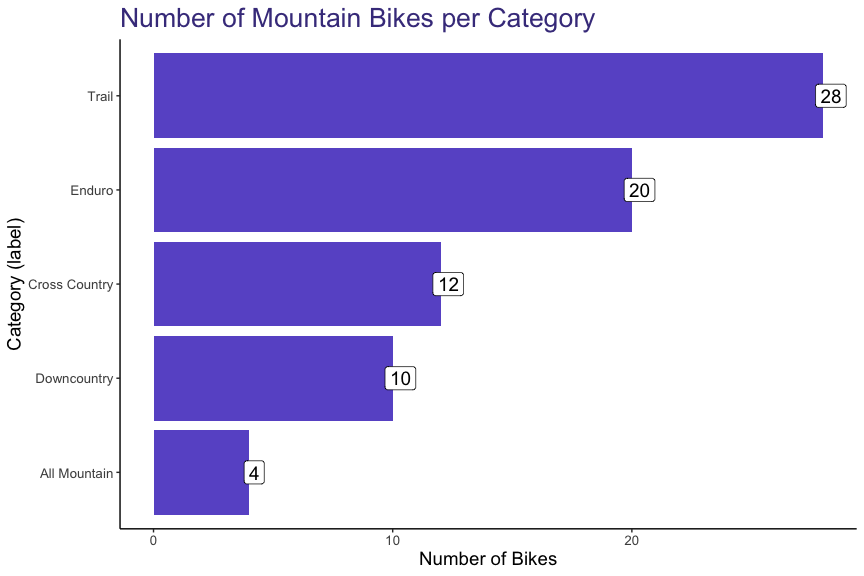

## Categorical Variables

There are 4 categorical variables we’ll take a look at to better understand our data:

1. Setting
2. Size
3. Front Piston (`f_piston`)
4. Rear Piston (`r_piston`)

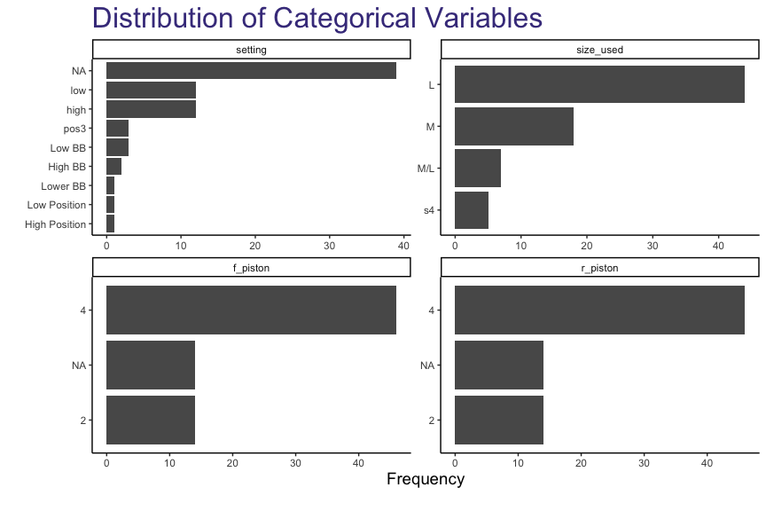

But, really, we care about understanding how these different variables interact with our target variable, `label`. Let’s look at their distribution and look for any patterns.

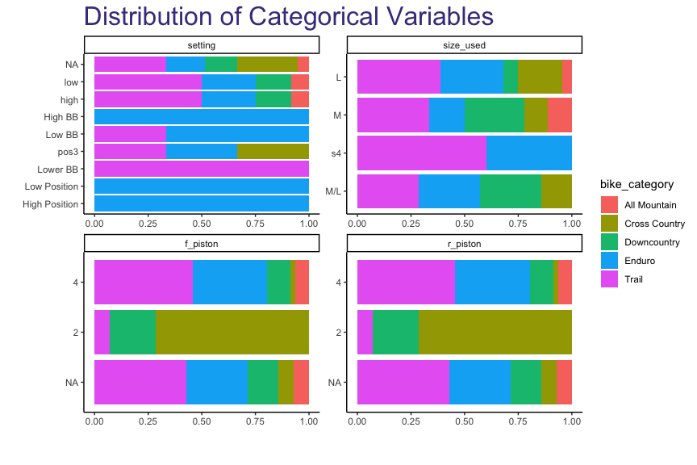

## Continuous Variables

To analyze the continuous features within our dataset, we built density plots for each of them to better understand their distribution.

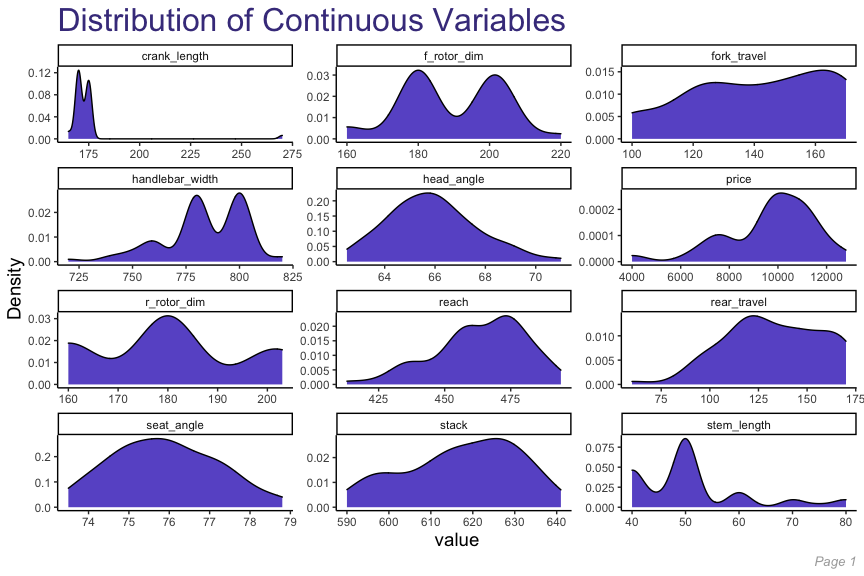

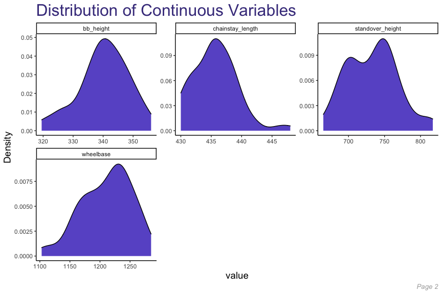

### Skewed Variables:

- Head_angle (skewed right)
- Handlebar_width (skewed left)
- Wheelbase (skewed left)

### Multi-Modal Distributed Variables:

- f_rotor_dim / r_rotor_dim
- Stem_length

Like we did for continuous variables, let’s look at the distribution of each of these predictors by our target variable, `label`, to look for any discernible patterns.

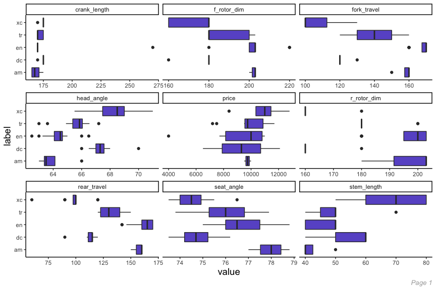

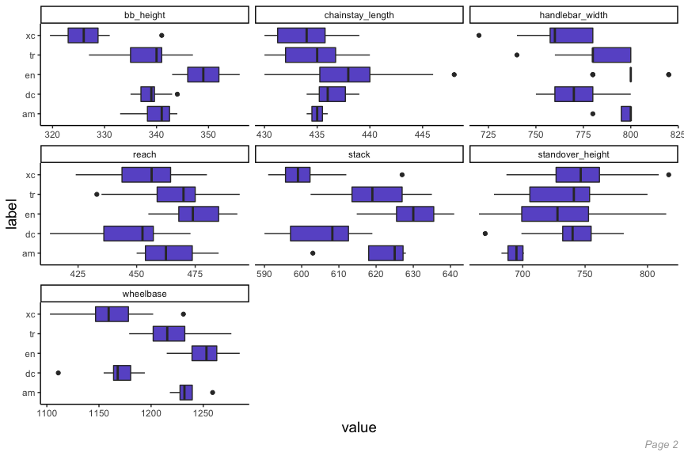

## Average bikes by flip-chip setting

Because some bikes’ websites would have two different “settings” for the same-sized bike, we opted to include both options and average the two together to get one middle-of-the-road estimate for that type of bike. We end up performing this operation for 47% of the bikes in our dataset.

# Methodology

Now that we have a better understanding of our mountain bike dataset, we’ll formulate a plan to prove the following hypothesis:

> **Applying our own clustering algorithms will either give us a different set number of clusters (rather than the 5 pre-ordained categories) OR will not provide clearly defined clusters, leading us to believe that the bikes are actually created on a spectrum and cannot be grouped into one of the 5 pre-ordained categories.**

To do so, we’ll:

- Try to use various methods to reduce the featureset and see if there are certain variables that can better be used to differentiate between different mountain bike categories.
- Apply various clustering and classification algorithms, including K-Means Clustering, Gaussian Mixture Models, and Multi-class Support Vector Machine, to disprove the notion that 5 distinct categories of Mountain Bikes exist.

# Variation Amongst Featureset

The first thing we’ll do is look to see if any of the features in our dataset are better at explaining the variation amongst the different bikes than other features. That is, it’s completely possible that two features are similar and don’t have much variation in them, even across some of the different bike categories. To do so, we’ll:

1. Look for highly correlated features and flag these for potential removal;
2. Run Principal Component Analysis (PCA) to see if certain features are better at explaining the variation in our data better than others.

## 1. Correlation

First, let’s take a look at our most highly correlated features. We’ll use the `corrplot()` function to better order the highly correlated features by the angular order of their eigenvectors.

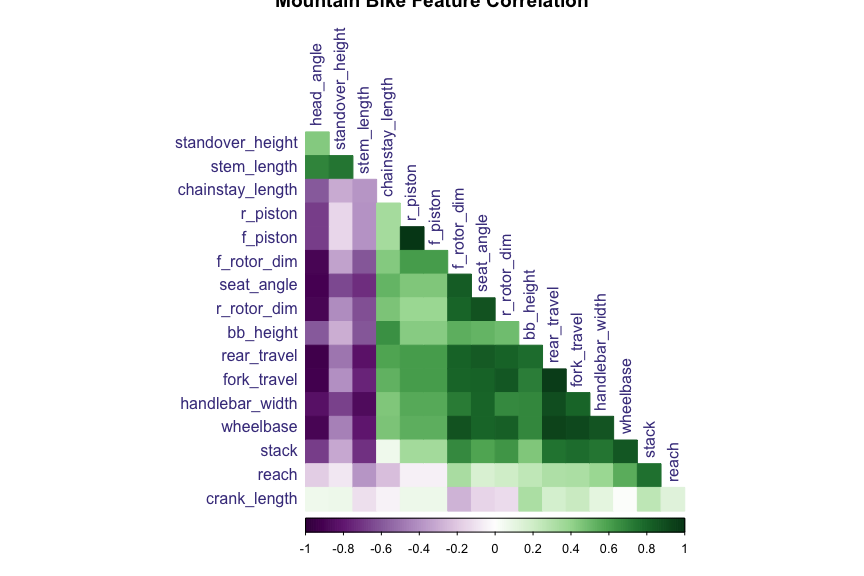

Here we see some obvious correlations, for example:

In all, here are the most highly correlated variables (i.e. variables which have a correlation above .9 or below -.9):

| variable | correlated_variable | correlation |
| --- | --- | --- |
| f_piston | r_piston | 1 |
| rear_travel | fork_travel | 0.9608 |
| rear_travel | wheelbase | 0.9301 |
| rear_travel | head_angle | -0.9219 |
| fork_travel | wheelbase | 0.9195 |
| fork_travel | head_angle | -0.9193 |
| head_angle | seat_angle | -0.9031 |

There are a solid amount, especially given that we only have 18 continuous columns in our dataset! For now, we’ll opt to include everything. But later on, as we analyze the importance of different features, we’ll look to remove some of the above variables first.

## 2. Principal Component Analysis (PCA)

Next, we’ll apply PCA to our dataset. In so doing, we’ll have to center and scale our data given how different the ranges are for certain measurements. Let’s take a look at our 5 principal components which explain the largest proportion of variance in the data:

|  | PC1 | PC2 | PC3 | PC4 | PC5 |
| --- | --- | --- | --- | --- | --- |
| **Standard deviation** | 3.024 | 1.262 | 1.164 | 1.071 | 0.8761 |
| **Proportion of Variance** | 0.538 | 0.09369 | 0.07977 | 0.06745 | 0.04515 |
| **Cumulative Proportion** | 0.538 | 0.6317 | 0.7115 | 0.7789 | 0.8241 |

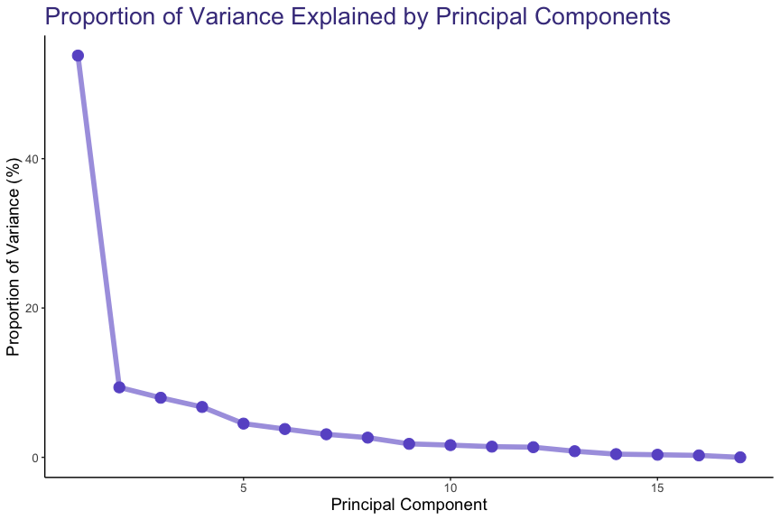

Let’s take a look at how our top 2 principal components explain the 5 different mountain bike categories:

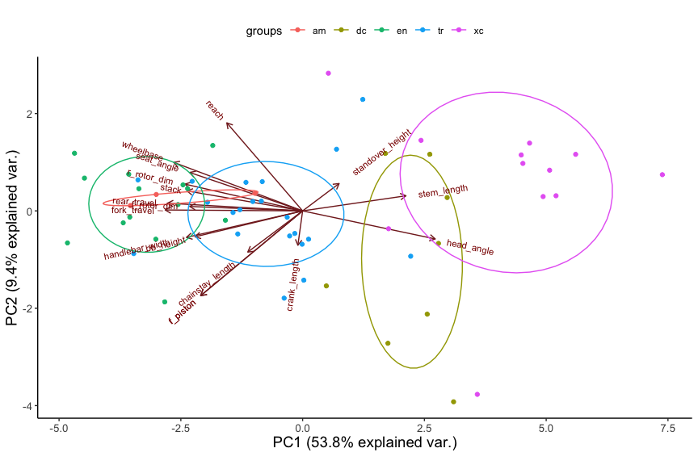

# Clustering

Because we are investigating the validity of mountain bike categories, one approach is to treat this dataset as unsupervised, stripping the bikes of their `label` and seeing if various clustering algorithms can re-create the 5 distinct `label`s. To do so, we’ll take a look at the following algorithms:

- K-Means
- Gaussian Mixture Models (GMM)
- Support Vector Machine (SVM)

## K-Means

We’ll start by using the K-Means Clustering algorithm, looking at various numbers of clusters (*k*) and seeing if the bikes logically group together.

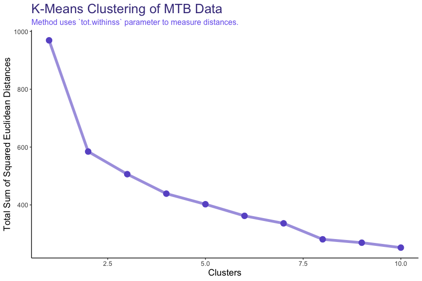

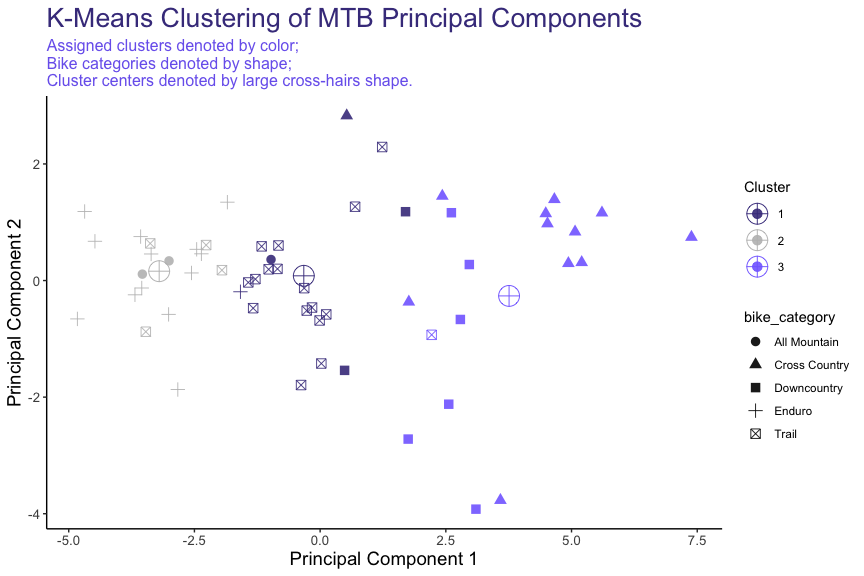

Overall, it’s clear that there is significant overlap between our Clusters, mainly along the Principal Component 1 axis; lending credence to the notion that our bikes can be differentiated along a single, continuous scale.

## Gaussian Mixture Model (GMM)

In this section, we’ll take a more probabilistic model to our clustering. That is, we’ll use a Guassian Mixture Model (GMM) to build out normally distributed subgroupings within our mountain bike dataset, where the densities of each of the subgroupings represents a probability that a bike belongs to that subgrouping. Unlike K-Means, which is a more centroid-based clustering method, GMM is more of a distribution-based clustering method.

Generally, what we expect to see is something like the following:

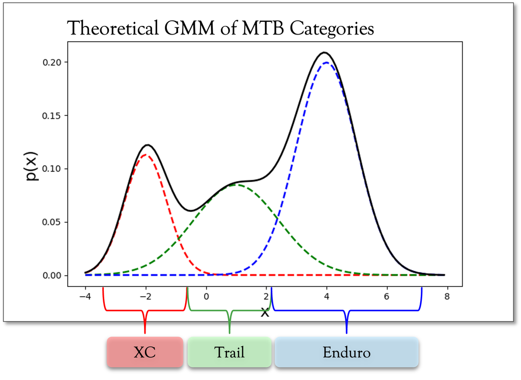

where, given a specific type of bike, we can predict the probability, $p(x)$ that a bike belongs to a category like `Cross Country (xc)` vs. `Trail` vs. `Enduro`.

```
## iteration: 1  num-clusters: 1
## iteration: 2  num-clusters: 2
## iteration: 3  num-clusters: 3
## iteration: 4  num-clusters: 4
## iteration: 5  num-clusters: 5
## iteration: 6  num-clusters: 6
## iteration: 7  num-clusters: 7
## iteration: 8  num-clusters: 8
## iteration: 9  num-clusters: 9
## iteration: 10  num-clusters: 10
```

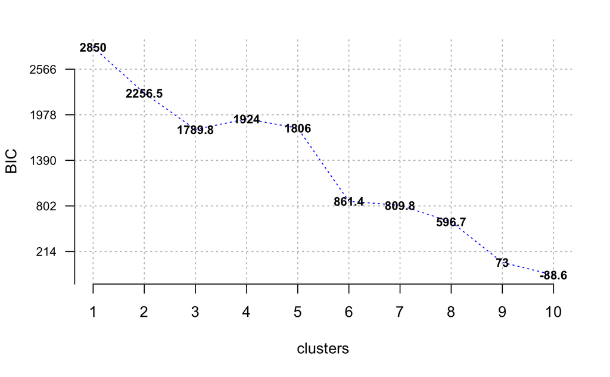

Optimal_GMM

| cluster_labels | am | dc | en | tr | xc |
| --- | --- | --- | --- | --- | --- |
| 1 | 1 | 0 | 5 | 11 | 1 |
| 2 | 2 | 1 | 9 | 8 | 0 |
| 3 | 0 | 7 | 0 | 2 | 11 |

Here we see the predicted cluster labels along with the actual 5 bike categories in our data. Trail and Enduro bikes are mostly grouped into Clusters 1 and 2, while Downcountry and Cross Country bikes are grouped into Cluster 3. This would lead us to believe that the original 5 bike categories can be sufficiently explained with fewer clusters.

Even so, let’s see how the probability of each bike belonging to a cluster appears by looking at the densities of each of the associated probabilities for a bike belonging to one of the cluster labels.

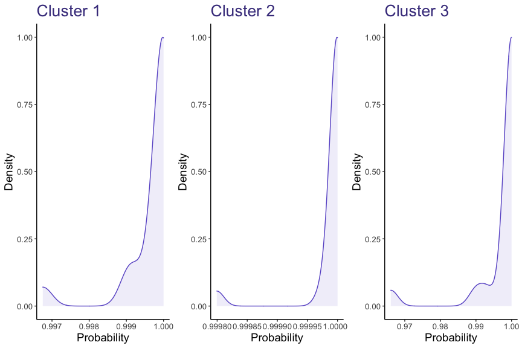

Above, we see the expected probability associated with predicting a correct class label. That is, the graph on the left shows how accurate the 3-cluster Gaussian Mixture Model was for predicting bikes fitting into Cluster #1. Generally, the probabilities for the predictions are all above .95; that is, GMM is extremely confident in grouping the different bikes into these 3 clusters.

## Multi-class SVM

If we took a slightly different approach and opted to treat our pre-assigned `label`s as truth, then we could approach this analysis as a supervised learning problem.

For this section, we chose to group the All Mountain and Enduro categories, since they completely overlapped in the PCA chart earlier. We also chose to switch the categorization of the Downcountry category, leaving it as a separate category and grouping it with both Trail and XC to experiment with the results of the model.

We chose to use a Multi-Class Support Vector Machine (SVM), and a grid search to tune the kernel functions and $\gamma$ values. For each set of parameters, we used 10-fold cross validation on all rows of the data. We decided against holding out data as a test set since we have such limited data, and the 10-fold CV should evaluate the model’s performance on blind data.

Using all of the data, the best SVM model was 73% accurate, using a Radial Basis kernel function with $\gamma=2.595024$

Treating the Downcountry category as XC, the best model was 81.6% accurate, with a Radial Basis kernel function with $\gamma=0.02983647$

Treating the Downcountry category as Trail, the best model was 80.0% accurate with a Radial Basis kernel function with $\gamma=3.764936$

Logically, grouping Downcountry bikes with one of their adjacent categories should naturally lead to an increase in performance; however, this could suggest that the Downcountry category is slightly more skewed towards the XC bikes.

To visualize the results of the SVM classifier, we mapped all features to the 2 Principal Components. In so doing, we were able to achieve a higher accuracy of 75% using a linear kernel, while continuing to treat the Downcountry category as its own distinct category.

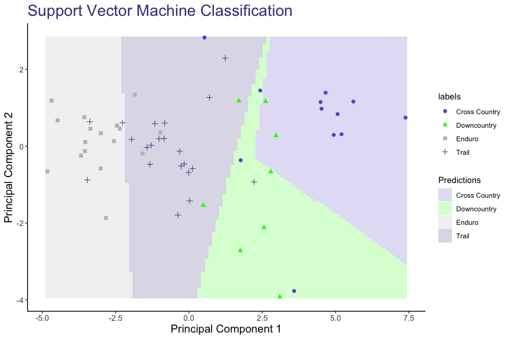

In the chart above, we can see how SVM closely maps the actual labels of the bike categories to their predicted categories. There are some misclassifications (when different colored dots appear in a differently shaded region), but overall the shaded SVM feature spaces seem to be accurate representations of the bike categories.

An interesting observation is that most of the boundary lines are more or less vertical, suggesting that most of the variation between classes is along Principal Component 1. We see this deviate between the XC and Downcountry boundary, however the validity of this boundary is still in question since the Downcountry category itself is more or less unofficial. Let’s try remapping Downcountry bikes to the Cross Country (XC) category and review the updated results.

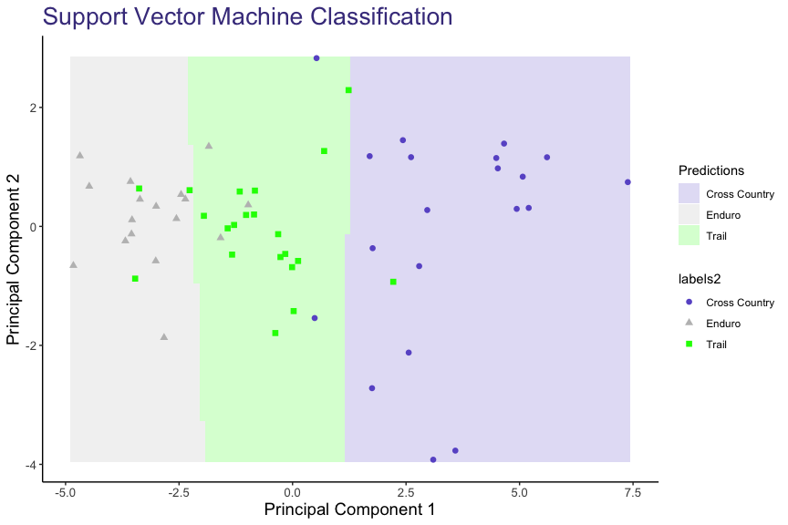

Mapping all Downcountry bikes to XC, the boundaries become almost entirely vertical, again suggesting that the classification of bikes can be attributed to Principal Component 1. The distinct regions appear to be accurate predictors of the 3 bike categories and are simple to explain, which would mean that we have effectively reduced the bias in our model.

# Conclusions

## Findings

- All results suggest that trying to discretely categorize full suspension mountain bikes is more or less arbitrary.
- The categorization of a mountain bike should be treated as on a continuous scale, with Cross Country (XC) bikes on one end and Enduro (EN) bikes on another.
- To obtain where a specific bike lies on this scale, one can use the linear combination of the bike’s specifications and the first principal component.
- This new spectrum of mapping bikes can provide bike manufacturers and consumers a method to quantify how a bike will handle when ridden.

Let’s look at an example from the data above. Some bike companies, like Transition and Revel, do not explicitly categorize their bikes like others do. For these brands, we categorized them based on general attributes, as well as media coverage of them. Let’s take a look at the Revel Ranger:

[figure not shown]

Revel_Ranger

| Rear Travel | Fork Travel | Front Piston | Front Rotor Diameter | Rear Piston | Rear Rotor Diameter | Head Angle | Seat Angle | Crank Length | Stem Length | Handlebar Width | Reach | Stack | Wheelbase | Chainstay Length | Bottom Bracket Height | Standover Height |
| --- | --- | --- | --- | --- | --- | --- | --- | --- | --- | --- | --- | --- | --- | --- | --- | --- |
| 115 | 120 | 2 | 180 | 2 | 160 | 67.5 | 75.3 | 170 | 40 | 780 | 473 | 619 | 1194 | 436 | 338 | 699 |

Converting to an input vector:
$$\text{Ranger} = \begin{bmatrix} 115 \\ 120 \\ 2 \\ 180 \\ 2 \\ 160 \\
67.5 \\ 75.3 \\ 170 \\ 40 \\ 780 \\ 473 \\ 619 \\ 1194 \\ 436 \\ 338 \\
699 \end{bmatrix} \rightarrow \text{ Ranger (scaled)} =
\begin{bmatrix} -0.61 \\ -0.80 \\ -1.68 \\ -0.53 \\ -1.68 \\
-1.30 \\ 0.79 \\ -0.39 \\ -0.40 \\-1.15 \\-0.11 \\0.60 \\0.16 \\-0.33
\\0.16 \\-0.16 \\ -1.01 \end{bmatrix} \text{and PC1}=\begin{bmatrix}
-0.31 \\ -0.31
\\ -0.23 \\
-0.26\\
-0.23\\
-0.27\\
0.30\\
-0.26\\
-0.01\\
0.24\\
-0.27\\
-0.17\\
-0.26\\
-0.30\\
-0.13\\
-0.25\\
0.08\end{bmatrix}$$

$$\text{Ranger} \times \text{PC1} = 1.7$$

Mapping the Revel Ranger to its first Principal Component we get a value of 1.7 which puts us right around the boundary between Trail and XC, which lines up with the PinkBike editors’ labelling of Downcountry in the [video](https://www.youtube.com/watch?v=JYQJbymyG6k) mentioned in the Project Overview section.

## Lessons Learned

As both authors of this report are in the midst of the [Online Masters of Science of Analytics (OMSA)](https://pe.gatech.edu/degrees/analytics) program, we feel that it provided reinforcement on previously seen data mining topics as well as good introductions to net new topics. Here are some individual takes on the lessons learned from the course.

**Mike:** I think this course was a great complement to [ISYE6740, Computational Data Analytics](https://www2.isye.gatech.edu/~yxie77/ISyE6740SyllabusSpring2018.pdf) (CDA), which was a bit more theory focused, e.g. requiring us to build ML algorithms from scratch, while this course seemed more practical focused, e.g. HW 5 allowing us to use machine learning methods on any dataset of our choice. Additionally, I think this course was a good course to take concurrently with Data Visual Analytics, as it also required the use of Random Forests, and provided a good introduction to data analysis techniques that are standard across any project (e.g. cross validation).

**Justin:** I really appreciated the practical nature of this course. I’ve already had the opportunity to use some of the classification and machine learning algorithms at work. Although this is a different take on ISYE 6740, Computational Data Analytics (CDA), I appreciated getting to do a similar-style course in my programming language of choice (R) and to get to really dive into the actual code, which has already paid numerous dividends in a practical setting. I took this course concurrently with [ISYE 6414](https://www.studocu.com/en-us/document/georgia-institute-of-technology/regression-analysis/isy-e-6414-syllabus-spring-2022/23788135), Regression Analysis. Although 6414 was recommended as a prerequisite for this course, it ended up being a nice pairing of courses.

## Course Suggestions

This course was a good introduction for practical applications. Some areas of improvement we would like to see included:

- Requiring more fundamental knowledge checks for some material. More specifically, we think the topics around Information Criterion and Discriminant analysis were glossed over too quickly. This course was our first exposure to those topics, so we’re not sure if they were intentionally light on the material since they are not used in industry as much.
- Additionally, we think the assignments in this course could have been more clear, however, we also think this could have been intentional to mimic the ambiguity of working in industry.
- A lot of the quizzes ended up needing (or at least seriously benefiting from) pre-written code based on the knowledge checks. Writing the code was fun to make the quizzes more bearable; however, we would’ve loved to see the instructor/TAs post this kind of code after the quiz due dates so students could benefit from understanding how to solve the problems in R.